# 1. Pre-processing

## 1.5 Wind Guest & Wind Speed

**Summary**

- Due to high correlations among the six wind-related variables (r ≈ 0.6–0.93), only Wind Speed (Max) is retained for clustering to avoid redundancy. Maximum wind speed provides the most representative measure of daily wind conditions, while the remaining variables are removed.
- The maximum daily wind speed is primarily used to detect the intensity of severe weather conditions such as gales, storms, tropical cyclones (typhoons and hurricanes), and tornadoes. From the boxplot, it clear that distibution of maximum weed speed in Basel over 9 years (summer and winter) is highly right-skewed, illustrating that most of days maximum wind speed range from 2 to 20, while the long tail indicates some unusual maximum weed speed. The largest one reached 59 km/h.

```python
df_describe_wind=df['Wind Speed (Max)'].describe()
df_describe_wind
```

```
count    1763.000000
mean       14.858762
std         7.871249
min         2.881557
25%         9.304952
50%        12.988194
75%        18.398964
max        59.192370
Name: Wind Speed (Max), dtype: float64
```

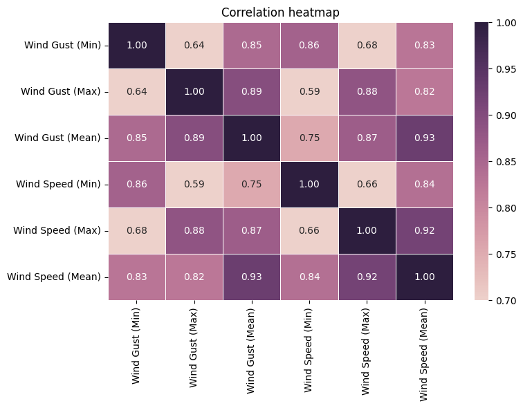

```python
corr = df.iloc[:, 12:18].corr(method='pearson')

plt.figure(figsize=(8, 6))
sns.heatmap(
    corr,
    cmap=sns.cubehelix_palette(as_cmap=True),
    annot=True,
    fmt=".2f",
    vmin=0.7,
    vmax=1,
    linewidths=0.5
)
plt.title("Correlation heatmap")
plt.savefig('heatmap_wind.png')
plt.tight_layout()
plt.show()
```

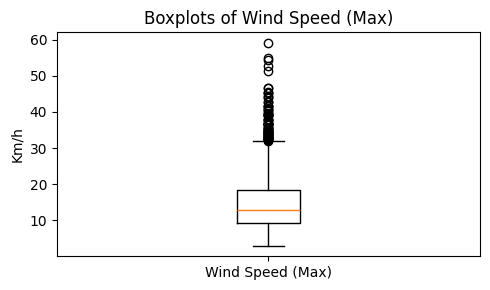

```python
plt.figure(figsize=(5,3))
plt.boxplot(df['Wind Speed (Max)'],tick_labels=['Wind Speed (Max)'])
plt.xticks()
plt.title('Boxplots of Wind Speed (Max)')
plt.ylabel('Km/h')
plt.tight_layout()
plt.show()
```

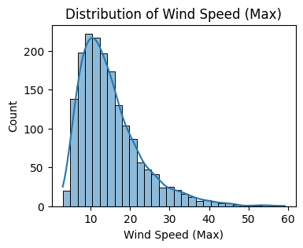

```python
fig=plt.figure(figsize=(4,3))
sns.histplot(df['Wind Speed (Max)'],kde=True,bins=30)
plt.title(f"Distribution of Wind Speed (Max)")
```